# PhyloMeth: Getting Trees and Data

Alex Faidiga

January 20, 2020

Let’s get some trees from Open Tree of Life. This is in some ways a successor to TreeBASE: another repository of trees (though it has only partial overlap with the trees in TreeBASE (or in another repository, Dryad). Unlike TreeBASE, anyone, not just the author, can add trees to Open Tree’s repository. Another important distinction is that Open Tree seeks to create a single tree for all life by creating essentially a supreme super tree.

Now let’s get ya tree, replacing the `eval=FALSE` with `eval=TRUE` and replacing the missing info.

```r
    library(rotl)
    library(ape)

 rosa.id <- tnrs_match_names("rosa")$ott_id
    # Now get Open Tree's current best estimate of the phylogeny for the group
    # They call this the tree of life; we can get the subtree for just this group.
    rosa.tree <- tol_subtree(ott_id=rosa.id)
```

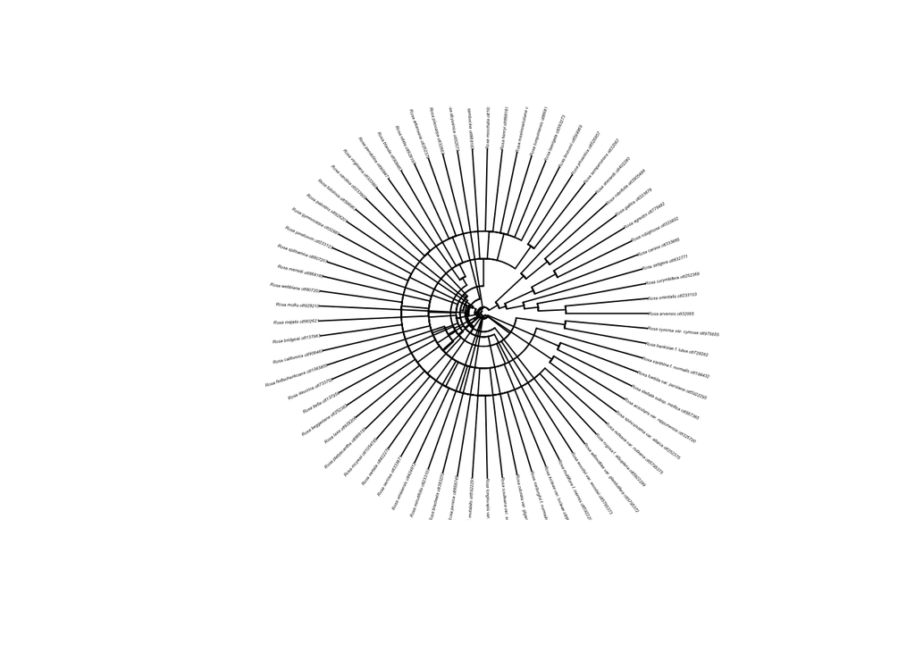

```r
    # Let's plot the tree:
    plot.phylo(rosa.tree, type="fan", cex=0.2)
```

It has a lot of polytomies, representing uncertainty. A maximally resolved tree (if rooted) will have one fewer internal nodes than terminal nodes: think of a tree with three taxa, ((A,B),C): it will have the MRCA of A and B and the MRCA of A, B, and C: three terminals, two internal nodes. If it had no information, it would only have one node. So we can look at the ratio of number of internal nodes to number of possible internal nodes to figure out how resolved a tree is (subtracting 1 from each to account for the root node that must always exist)

```
## [1] "The rosa tree has 69 terminals and 68 internal nodes out of 67 possible, which means it is 101.52% resolved"
```

Open Tree can also return the original studies with the source trees.

```r
    rosa.studies <- studies_find_studies(property="ot:focalCladeOTTTaxonName",
    value="Rosa")
    rosa.studies.ids <- unlist(rosa.studies$study_ids)
  rosa.tree.ids <- unlist(rosa.studies$tree_ids)
    # Let's get info on the first study
  # Note: I did the second study instead because it only has one tree associated with it, which makes plotting the tree easier down the line.
    rosa.study1.metadata <- get_study_meta(rosa.studies[[1]][[2]])
    print(get_publication(rosa.study1.metadata))
```

```
## [1] "Bruneau, A. [et al. 2007], Starr, J. R., & Joly, S. 2007. Phylogenetic relationships in the genus Rosa: New evidence from chloroplast DNA sequences and an appraisal of current knowledge. Syst. Bot. 32: 366-378."
```

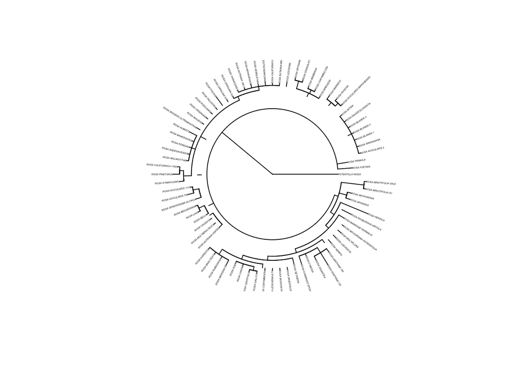

```r
    # And let's get the tree from this study
    # Look in rotl documentation for the right function
    # Hint: get_study_trees() is close, but you don't know the tree.id
    # Note: I do know the tree ID so I just used get_study_tree.
  rosa.study1.tree1 <- get_study_tree(rosa.studies.ids[[2]], rosa.tree.ids[[2]])

  # And plot it
    plot.phylo(rosa.study1.tree1, type="fan", cex=0.2)
```

```r
    #Return both trees
    return.list <- list(rosa.tree, rosa.study1.tree1)
    names(return.list) <- c("tol.tree", "study1.tree")
    return.list
```

```
## $tol.tree
##
## Phylogenetic tree with 69 tips and 68 internal nodes.
##
## Tip labels:
##  Rosa_arvensis_ott32065, Rosa_orientalis_ott233103, Rosa_corymbifera_ott252369, Rosa_setigera_ott832771, Rosa_canina_ott333885, Rosa_rubiginosa_ott333892, ...
## Node labels:
##  Rosa ott259066, , , , , , ...
##
## Rooted; no branch lengths.
##
## $study1.tree
##
## Phylogenetic tree with 80 tips and 32 internal nodes.
##
## Tip labels:
##  POTENTILLA_NIVEA, ROSA_FOETIDA, ROSA_PRIMULA, ROSA_ACICULARIS_2, ROSA_ARKANSANA, ROSA_BLANDA_1, ...
##
## Rooted; includes branch lengths.
```

Another question is where to get data. One important way is to collect your own: go out and measure seed size, count insect hairs, measure polar bear weight, etc. However, another way is to gather data already published by others. As with trees, it is important to *cite your sources*. People have put a lot of work into gathering data, and citation is the main way they get credit. It is also an essential way to reward people who choose to share data for others to build upon, correct, and check for reproducibility (some researchers still choose not to share data). Having citations also lets you and future scientists check for problems.

There are many places to get data. Perhaps the most convenient is to use [rOpenSci’s packages](https://ropensci.org/packages/), which have interfaces to places like [Barcode of Life](https://github.com/ropensci/bold), [GBIF](https://github.com/ropensci/rgbif), [Encyclopedia of Life](https://github.com/ropensci/reol), [Neotoma paleoecological database](https://github.com/ropensci/neotoma), [Fishbase](https://github.com/ropensci/rfishbase), and much more. A major source for datasets and supplemental from particular papers is the [Dryad](http://datadryad.org) site. For plant traits, the [TRY database](https://www.try-db.org/TryWeb/Home.php), which has many different datasets, can be useful, though policies on sharing can differ by dataset. [Morphbank](http://www.morphbank.net) has biological images while [Morphobank](https://morphobank.org) has images and other phenotypic data. Katherine Bannar-Martin has a [list](http://www.khbannarmartin.com/online-databases/) of databases for biological anthropology, mammals, fish, other vertebrates, plants, and more.

For homework, consider what biological question you’re curious about and gather data for it. Importantly, **look at the data** before using it. Data are messy. For example, take latitude and longitude. Nice, continuous numbers: not “smooth vs hairy” but something you just read from your GPS – sure, there may be some imprecision, but it’s not that bad, right? However, such data are full of errors: incorrect taxonomy, dropping signs or direction labels (140.5 W longitude is -140.5, not 140.5), entering 0,0 for missing data rather than leaving blank, recording the location of the collection where the specimen is housed rather than where it was collected, recording location of specimens under cultivation or in captivity (a polar bear in the San Diego Zoo), or just simple errors. Other kinds of data have their own problems: fish length – is it snout to end of tail fin, snout to vent? Is it for the biggest adult (beware indeterminate growth), average adult, whatever fish, adult or juvenile, was caught? For plant growth habit, how are woody vines counted: as woody (since they have woody structure) or herbaceous (not self supporting or tall)? Any time continuous variation is put into discrete bins, there are weird corner cases – after all, it’s very rare for a trait to change instantly in one generation, even seemingly discrete ones like presence of eyes (what about cave fish?) or number of limbs (skinks? male boa constrictors with pelvic spurs?).

# Homework: Get data from an external source, load the data in, plot the data, summarize the data, etc. to make sure there are no weird values.

I am interested in how many independent losses of cleistogamy have occured in Viola, and if this loss is associated with environmental variables. My hypothesis is that cleistogamy has been lost independently several times across the phylogeny, and that this loss is associated with a shift to warmer, drier habitats with greater light availability. This is because such habitats have greater light (and probably pollinator) availability, and thus cleistogamy is not necessary to ensure reproductive success.

Type of data I will need: + sequences to build viola phylogeny (whole genus of ~600 sp.? or focus on north american violets?) + environmental data, e.g. mean temperature, soil moisture, habitat type + presence or absence of cleistogamy in a given species

Because occurrence data do not come with envnironmental data, I will try to download occurrence data for V. rostrata and V. pedata from GBIF and do some simple comparisons for their ranges (e.g. how many states do they occur in, how many observations, phenology, etc.)

## Using the rgbif package

### Obtaining taxa keys and estimating occurrence data

```r
library(rgbif)
#two CL species:
name_suggest(q='Viola rostrata')
```

```
## # A tibble: 11 x 3
##        key canonicalName              rank
##  *   <int> <chr>                      <chr>
##  1 5331225 Viola rostrata             SPECIES
##  2 7766886 Viola rostrata             SPECIES
##  3 7296287 Viola rostrata rostrata    VARIETY
##  4 7296286 Viola rostrata rostrata    FORM
##  5 7434730 Viola rostrata japonica    SUBSPECIES
##  6 5663541 Viola rostrata elongata    VARIETY
##  7 6711835 Viola rostrata japonica    VARIETY
##  8 8104952 Viola rostrata phelpsiae   FORM
##  9 5663522 Viola rostrata trirostrata FORM
## 10 5663548 Viola rostrata alpina      FORM
## 11 5663528 Viola rostrata phelpsiae   VARIETY
```

```r
name_suggest(q='Viola pubescens')
```

```
## # A tibble: 22 x 3
##        key canonicalName                  rank
##  *   <int> <chr>                          <chr>
##  1 5331338 Viola pubescens                SPECIES
##  2 9077732 Viola pubescens scabriuscula   FORM
##  3 5664646 Viola pubescens achlydophylla  FORM
##  4 5664628 Viola pubescens eriocarpa      VARIETY
##  5 5664610 Viola pubescens glabriuscula   VARIETY
##  6 5664569 Viola pubescens scabriuscula   VARIETY
##  7 8852854 Viola pubescens scabriuscula   FORM
##  8 5664564 Viola pubescens typica         VARIETY
##  9 6711811 Viola pubescens brevistipulata VARIETY
## 10 5708737 Viola pubescens leiocarpon     VARIETY
## # … with 12 more rows
```

```r
#two non-CL species:
name_suggest(q='Viola pedata')
```

```
## # A tibble: 24 x 3
##        key canonicalName               rank
##  *   <int> <chr>                       <chr>
##  1 5331278 Viola pedata                SPECIES
##  2 8619549 Viola pedata concolor       VARIETY
##  3 7414748 Viola pedata bicolor        FORM
##  4 7942672 Viola pedata lineariloba    FORM
##  5 5663588 Viola pedata alba           FORM
##  6 8209010 Viola pedata alba           VARIETY
##  7 8367871 Viola pedata rosea          FORM
##  8 5331280 Viola pedata ranunculifolia VARIETY
##  9 5663553 Viola pedata inornata       VARIETY
## 10 5663579 Viola pedata bicolor        VARIETY
## # … with 14 more rows
```

```r
name_suggest(q='Viola canadensis')
```

```
## # A tibble: 18 x 3
##         key canonicalName                rank
##  *    <int> <chr>                        <chr>
##  1  5331231 Viola canadensis             SPECIES
##  2  8063792 Viola canadensis scopulorum  SUBSPECIES
##  3  8037347 Viola canadensis sitchensis  VARIETY
##  4  7226050 Viola canadensis canadensis  VARIETY
##  5  5664140 Viola canadensis pubens      VARIETY
##  6  8510244 Viola canadensis corymbosa   VARIETY
##  7  5664146 Viola canadensis neomexicana SUBSPECIES
##  8  7381065 Viola canadensis neomexicana VARIETY
##  9  5664111 Viola canadensis scopulorum  VARIETY
## 10  5664135 Viola canadensis rugulosa    VARIETY
## 11  5664161 Viola canadensis corymbosa   VARIETY
## 12  5664117 Viola canadensis scariosa    VARIETY
## 13  5664105 Viola canadensis sitchensis  VARIETY
## 14  5664123 Viola canadensis rydbergii   SUBSPECIES
## 15 10136630 Viola canadensis scopulorum  SUBSPECIES
## 16 10395617 Viola canadensis rydbergii   SUBSPECIES
## 17  8267618 Viola canadensis scariosa    VARIETY
## 18  7925493 Viola canadensis rydbergii   VARIETY
```

There are two species keys for viola rostrata: 5331225 and 7766886. Pedata has one: 5331278.

```
## [1] "Viola rostrata with key #5331225 has 1561 occurrences in the US."
```

```
## [1] "Viola rostrata with key #7766886 has 2 occurrences in the US."
```

```
## [1] "Viola pubescens with key #5331338 has 5612 occurrences in the US."
```

```
## [1] "Viola pedata with key #5331278 has 3580 occurrences in the US."
```

```
## [1] "Viola canadensis with key #5331231 has 3403 occurrences in the US."
```

```
## # A tibble: 2 x 62
##   key   scientificName issues datasetKey publishingOrgKey installationKey
## * <chr> <chr>          <chr>  <chr>      <chr>            <chr>
## 1 2243… Viola rostrat… ""     b740eaa0-… a344ee9f-f1b7-4… 4c5fccfd-c052-…
## 2 2243… Viola rostrat… ""     b740eaa0-… a344ee9f-f1b7-4… 4c5fccfd-c052-…
## # … with 56 more variables: publishingCountry <chr>, protocol <chr>,
## #   lastCrawled <chr>, lastParsed <chr>, crawlId <int>, extensions <chr>,
## #   basisOfRecord <chr>, taxonKey <int>, kingdomKey <int>, phylumKey <int>,
## #   classKey <int>, orderKey <int>, familyKey <int>, genusKey <int>,
## #   speciesKey <int>, acceptedTaxonKey <int>, acceptedScientificName <chr>,
## #   kingdom <chr>, phylum <chr>, order <chr>, family <chr>, genus <chr>,
## #   species <chr>, genericName <chr>, specificEpithet <chr>, taxonRank <chr>,
## #   taxonomicStatus <chr>, year <int>, month <int>, day <int>, eventDate <chr>,
## #   modified <chr>, lastInterpreted <chr>, license <chr>, identifiers <chr>,
## #   facts <chr>, relations <chr>, class <chr>, countryCode <chr>,
## #   country <chr>, rightsHolder <chr>, identifier <chr>, recordNumber <chr>,
## #   informationWithheld <chr>, institutionID <chr>, nomenclaturalCode <chr>,
## #   datasetName <chr>, gbifID <chr>, occurrenceID <chr>, type <chr>,
## #   preparations <chr>, catalogNumber <chr>, recordedBy <chr>,
## #   institutionCode <chr>, name <chr>, verbatimEventDate <chr>
```

There are only two records for rostrata key #7766886, and they are a species identification that I’ve never seen before. They don’t have lat-long data so I won’t use them anyway.

### Creating data frames with occurrence data for each species

```r
rostrata_data <- occ_search(
  taxonKey = rostrata_key1,
  return = "data",
  country = "US",
  hasCoordinate = TRUE,
  hasGeospatialIssue= FALSE,
  limit = 4000,
  fields = c('scientificName', 'specificEpithet', 'eventDate', 'year', 'month', 'day', 'decimalLatitude', 'decimalLongitude', 'elevation', 'verbatimLocality', 'stateProvince', 'basisOfRecord', 'institutionCode'))

pubescens_data <- occ_search(
  taxonKey = pubescens_key,
  return = "data",
  country = "US",
  hasCoordinate = TRUE,
  hasGeospatialIssue= FALSE,
  limit = 4000,
  fields = c('scientificName', 'specificEpithet', 'eventDate', 'year', 'month', 'day', 'decimalLatitude', 'decimalLongitude', 'elevation', 'verbatimLocality', 'stateProvince', 'basisOfRecord', 'institutionCode'))

pedata_data <- occ_search(
  taxonKey = pedata_key,
  return = "data",
  country = "US",
  hasCoordinate = TRUE,
  hasGeospatialIssue= FALSE,
  limit = 4000,
  fields = c('scientificName', 'specificEpithet', 'eventDate', 'year', 'month', 'day', 'decimalLatitude', 'decimalLongitude', 'elevation', 'verbatimLocality', 'stateProvince', 'basisOfRecord', 'institutionCode'))

canadensis_data <- occ_search(
  taxonKey = canadensis_key,
  return = "data",
  country = "US",
  hasCoordinate = TRUE,
  hasGeospatialIssue= FALSE,
  limit = 4000,
  fields = c('scientificName', 'specificEpithet', 'eventDate', 'year', 'month', 'day', 'decimalLatitude', 'decimalLongitude', 'elevation', 'verbatimLocality', 'stateProvince', 'basisOfRecord', 'institutionCode'))
```

Now I have four datasets of occurrence data for violet species occurring in the U.S. that have geospatial data with (supposedly) no issues.

```
## [1] "Number of rostrata occurrences in TN: 48"
```

```
## [1] "Number of pubescens occurrences in TN: 56"
```

```
## [1] "Number of pedata occurrences in TN: 45"
```

```
## [1] "Number of candensis occurrences in TN: 38"
```

I’d like to know how many different states each species occurs in, but I have to figure out the R code first.

### Plotting GBIF occurrence data

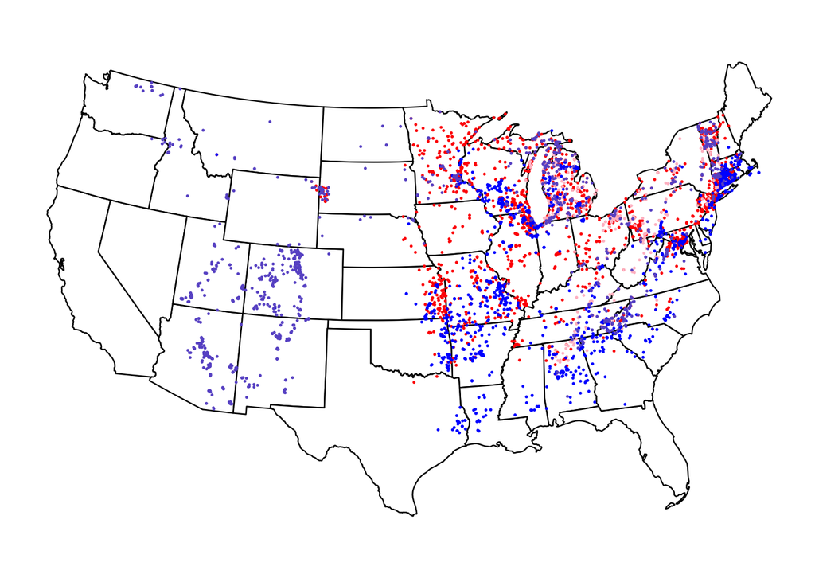

This mapping function is weird and it’s too hard to figure out how to add a legend here. Reds = 2 CL species, blues = 2 non-CL species.